# 04 Visualizations

J Andres Gannon, Danil Gromakov, Katelyn Hess, and Yulia Krylova

May 2020

This document produces some descriptive summary statistics of the new data collected regarding US prosecutor and Department of Justice officials appointed during the Trump administration

# Load data

We use the aggregated and combined data on both DOJ officials and prosecutors here

```r
df <- read.csv(file = paste0(here::here(), '/data/all_noemploy.csv'))
df_employ <- read.csv(file = paste0(here::here(), '/data/all_withemploy.csv'))
```

```r
df <- read.csv(file = paste0(here::here(), '/data/all_noemploy.csv'))
# df_employ <- read.csv(file = paste0(here::here(), '/data/all_withemploy.csv'))
```

# Analyze data quality

## Missingness

We identify which columns are missing data. Much of the missingness is insignificant, since most personnel do not have doctorates or known membership in some of these societies. We do not convert these NAs to 0’s because not finding information confirming their membership does not mean they were not members of these organizations

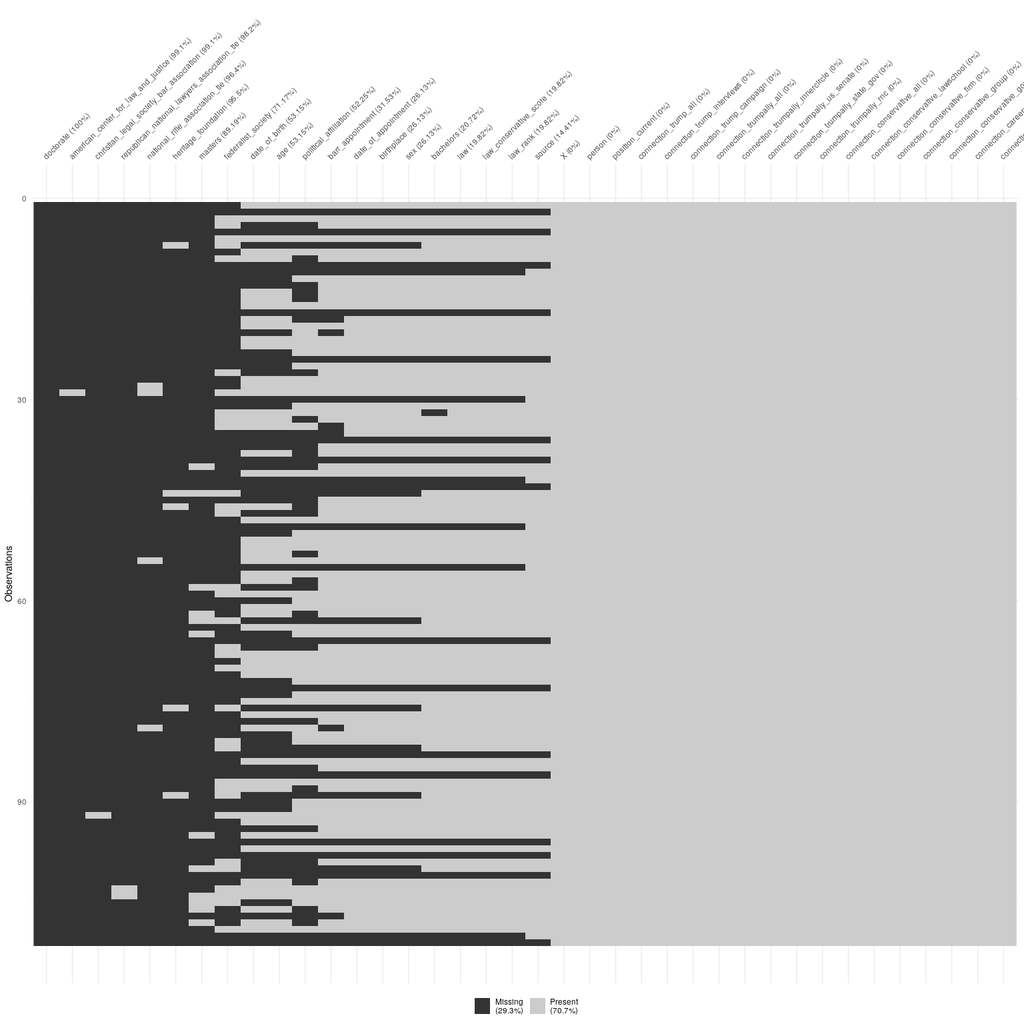

```r
visdat::vis_miss(df, sort_miss = TRUE)
```

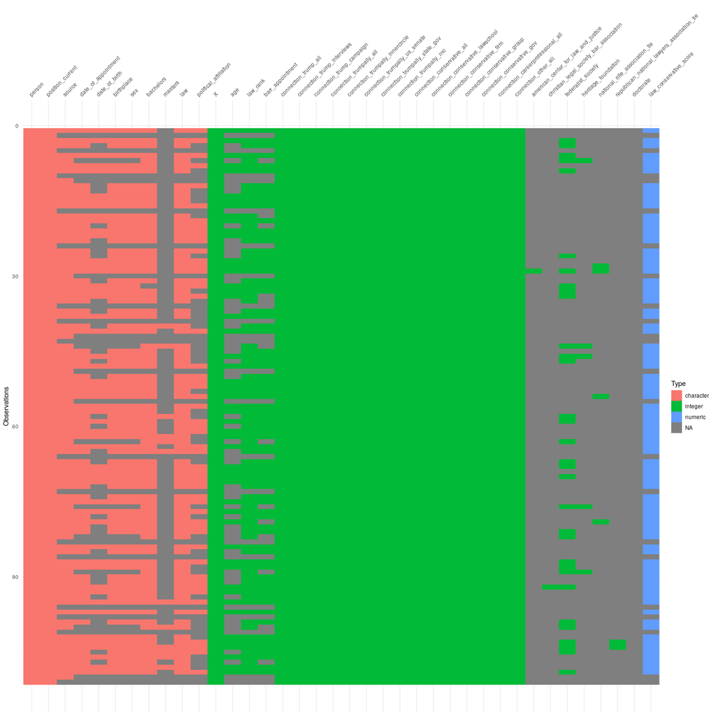

```r
visdat::vis_dat(df)
```

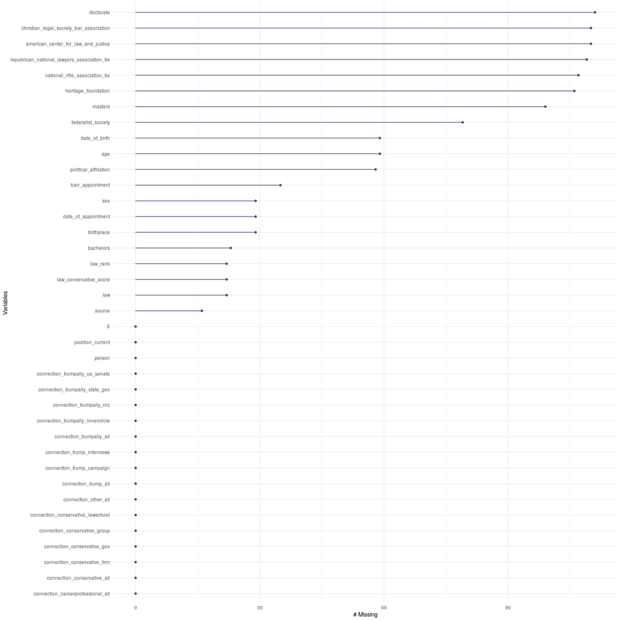

```r
naniar::gg_miss_var(df)
```

## Covariate distributions

We can examine distributions of the numeric variables to identify outliers or problems in data quality. Everything looks largely correct

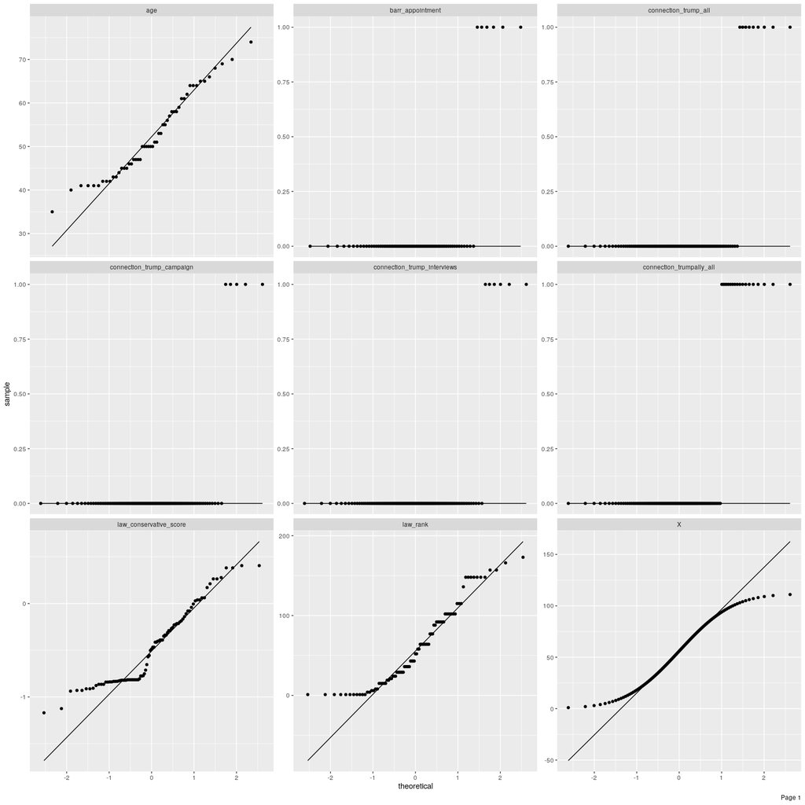

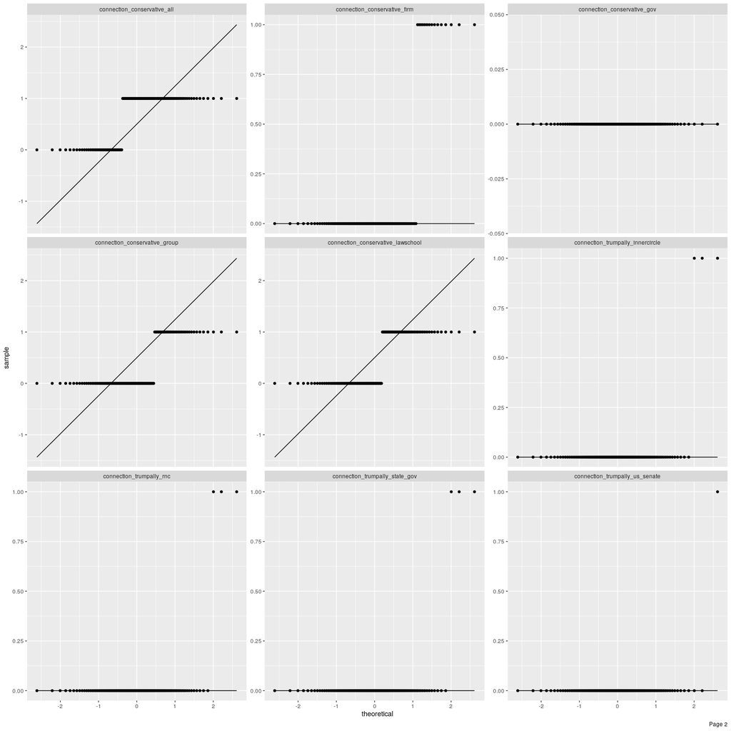

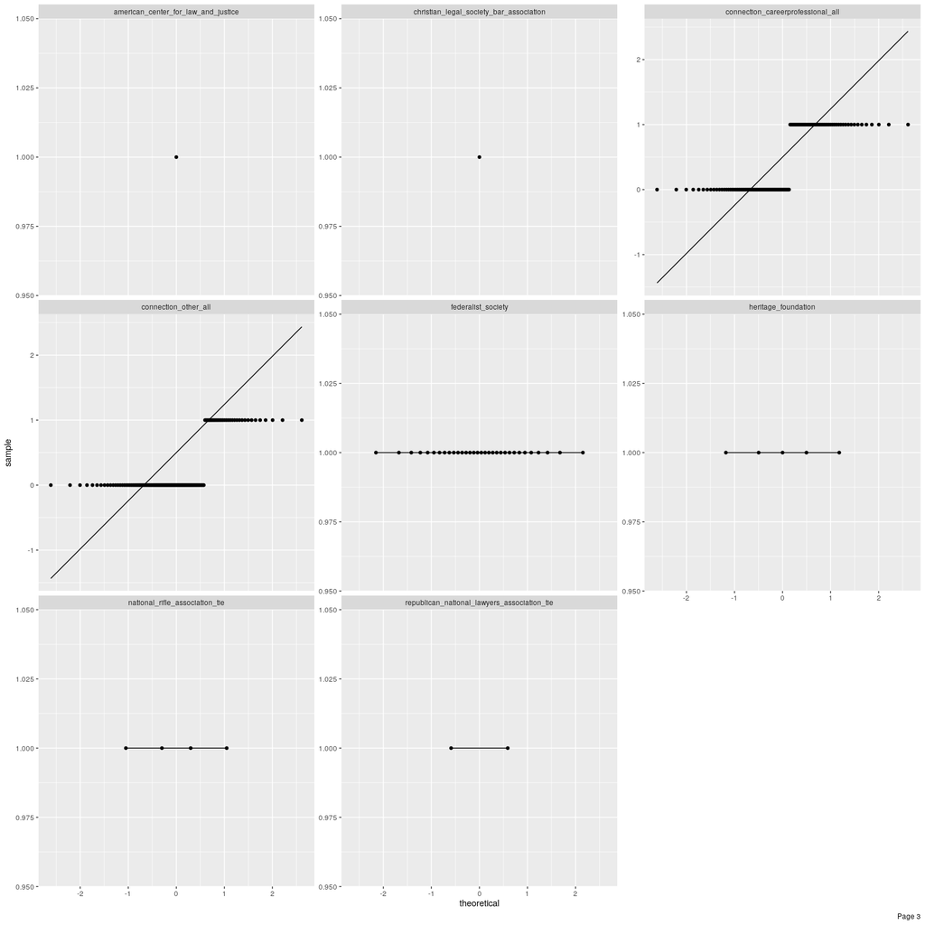

```r
DataExplorer::plot_qq(df)
```

```r
DT::datatable(funModeling::df_status(df))
```

| variable | q_zeros | p_zeros | q_na | p_na | q_inf | p_inf | type | unique |
| --- | --- | --- | --- | --- | --- | --- | --- | --- |
| X | 0 | 0.00 | 0 | 0.00 | 0 | 0 | integer | 111 |
| person | 0 | 0.00 | 0 | 0.00 | 0 | 0 | character | 111 |
| position_current | 0 | 0.00 | 0 | 0.00 | 0 | 0 | character | 106 |
| source | 0 | 0.00 | 16 | 14.41 | 0 | 0 | character | 2 |
| date_of_appointment | 0 | 0.00 | 29 | 26.13 | 0 | 0 | character | 49 |
| date_of_birth | 0 | 0.00 | 59 | 53.15 | 0 | 0 | character | 38 |
| age | 0 | 0.00 | 59 | 53.15 | 0 | 0 | integer | 26 |
| birthplace | 0 | 0.00 | 29 | 26.13 | 0 | 0 | character | 43 |
| sex | 0 | 0.00 | 29 | 26.13 | 0 | 0 | character | 2 |
| bachelors | 0 | 0.00 | 23 | 20.72 | 0 | 0 | character | 72 |

[output cut: 28 more lines]

|  | variable | q_zeros | p_zeros | q_na | p_na | q_inf | p_inf | type | unique |
| --- | --- | --- | --- | --- | --- | --- | --- | --- | --- |
| 1 | X | 0 | 0 | 0 | 0 | 0 | 0 | integer | 111 |
| 2 | person | 0 | 0 | 0 | 0 | 0 | 0 | character | 111 |
| 3 | position_current | 0 | 0 | 0 | 0 | 0 | 0 | character | 106 |
| 4 | source | 0 | 0 | 16 | 14.41 | 0 | 0 | character | 2 |
| 5 | date_of_appointment | 0 | 0 | 29 | 26.13 | 0 | 0 | character | 49 |
| 6 | date_of_birth | 0 | 0 | 59 | 53.15 | 0 | 0 | character | 38 |
| 7 | age | 0 | 0 | 59 | 53.15 | 0 | 0 | integer | 26 |
| 8 | birthplace | 0 | 0 | 29 | 26.13 | 0 | 0 | character | 43 |
| 9 | sex | 0 | 0 | 29 | 26.13 | 0 | 0 | character | 2 |
| 10 | bachelors | 0 | 0 | 23 | 20.72 | 0 | 0 | character | 72 |

[output cut: 28 more lines]

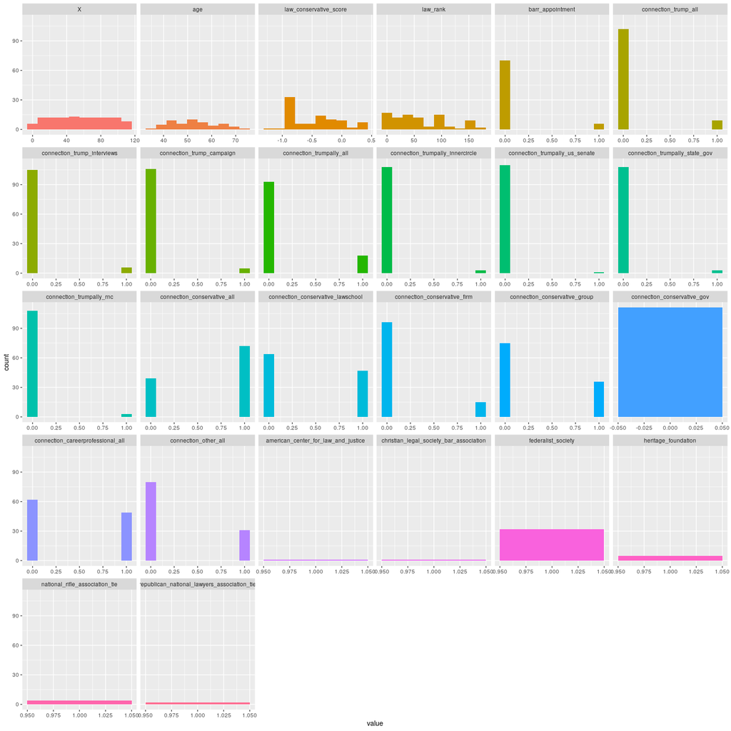

```r
funModeling::plot_num(df)
```

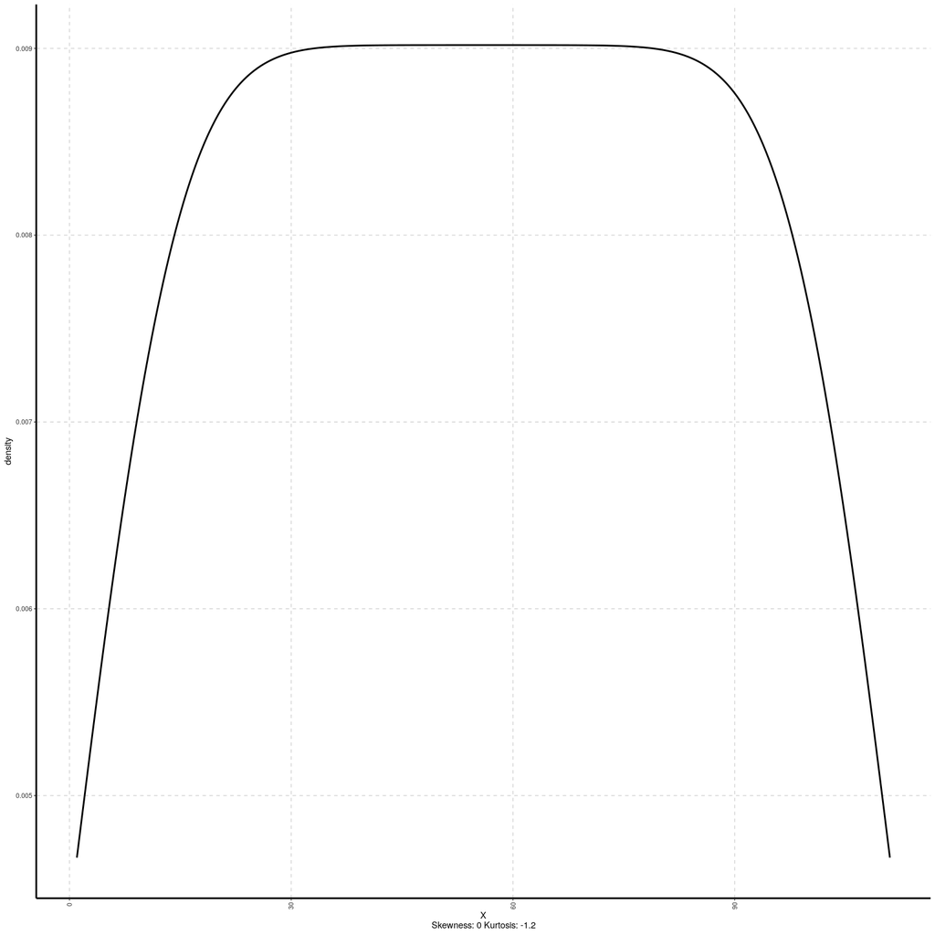

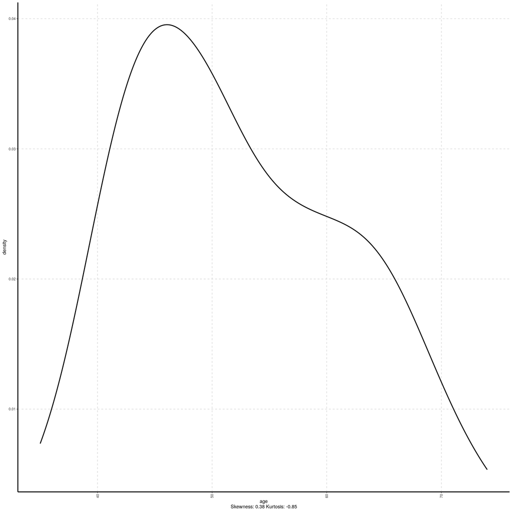

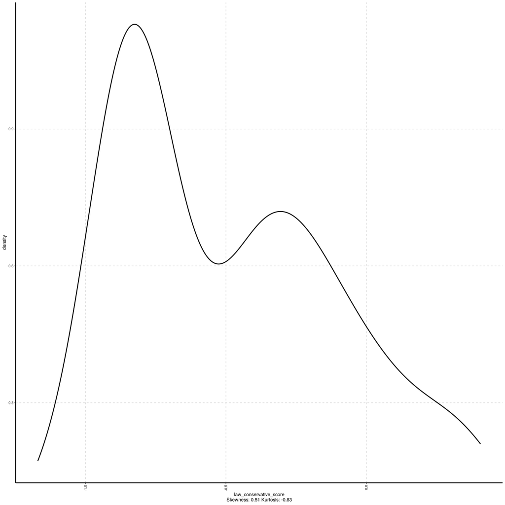

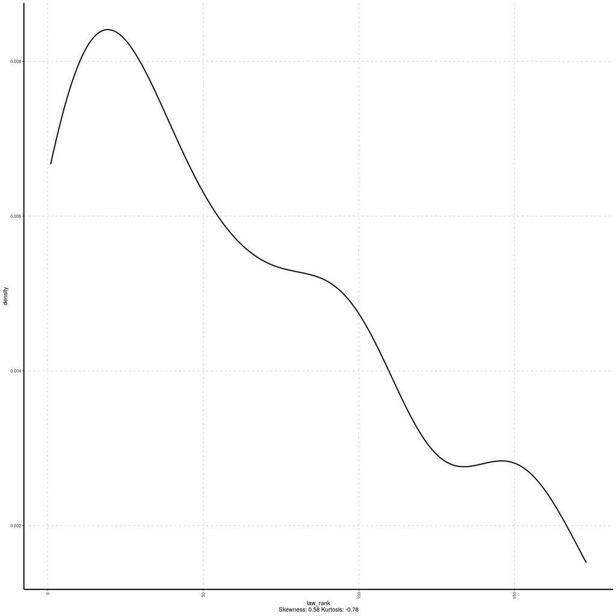

```r
SmartEDA::ExpNumViz(df)
```

# Law school rankings

[figure not shown]

```r
school <- read.csv(file = paste0(here::here(), '/data/ideology_lawschool.csv'))
school$score_scaled <- scale(school$conservatism)

school <- school %>% dplyr::select(-c("conservatism"))

df_law <- df %>% dplyr::select(person, law) %>%
  dplyr::distinct() %>%
  dplyr::rename(school = law) %>%
  dplyr::group_by(school) %>%
  dplyr::summarise(count = dplyr::n_distinct(person)) %>%
  dplyr::rename(persons = count)

df_law$trump <- 1

school_all <- dplyr::left_join(school, df_law)
school_all$school <- reorder(school_all$school, school_all$rank)
school_all$trump[is.na(school_all$trump)] <- 0
school_all$persons[is.na(school_all$persons)] <- 0
school_all$trump <- as.factor(school_all$trump)
school_all$labels <- school_all$school
school_all$labels[school_all$trump == 0] <- NA

ggplot2::ggplot(school_all, aes(x = reorder(school, dplyr::desc(school)) , y = score_scaled, color = trump)) +
  geom_point() +
  coord_flip() +
#  scale_x_discrete(labels = school_all$labels) +
  scale_color_manual(breaks = c("0", "1"), values = c("black", "red")) +
  theme_light() +
  theme(axis.text.y = element_blank(),
        text = element_text(size = 14)) +
  guides(color = FALSE) +
  labs(title = "Law School Ideology Bias in Trump Prosecutors", x = "Law Schools in Rank Order", y = "Liberal-Conservative Scale")
```

# Membership overlaps

```r
# Trump ties
upset_trump <- df %>% dplyr::select(dplyr::starts_with("connection_trump_")) %>%
  dplyr::select(-c("connection_trump_all")) %>%
  dplyr::rename("Trump personal interview" = connection_trump_interviews, "Trump campaign connection" = connection_trump_campaign)

UpSetR::upset(upset_trump,
      number.angles = 0, point.size = 3.5, line.size = 2, text.scale = 2,
      mainbar.y.label = "Officials", order.by = "freq")
```

[figure not shown]

```
geom_path: Each group consists of only one observation. Do you need to adjust the group aesthetic?
```

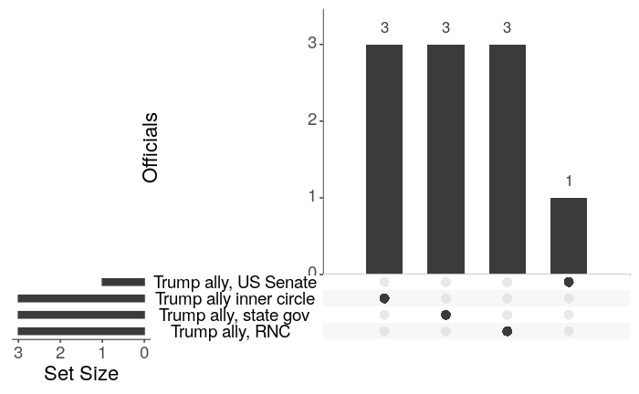

```r
# Trump ally ties
upset_trumpally <- df %>% dplyr::select(dplyr::starts_with("connection_trumpally_")) %>%
  dplyr::select(-c("connection_trumpally_all")) %>%
  dplyr::rename("Trump ally inner circle" = connection_trumpally_innercircle, "Trump ally, US Senate" = connection_trumpally_us_senate, "Trump ally, state gov" = connection_trumpally_state_gov, "Trump ally, RNC" = connection_trumpally_rnc)

UpSetR::upset(upset_trumpally,
      number.angles = 0, point.size = 3.5, line.size = 2, text.scale = 2,
      mainbar.y.label = "Officials", order.by = "freq")
```

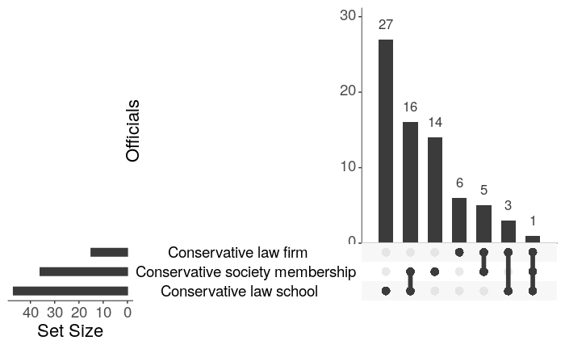

```r
# Conservative group ties
upset_conservative <- df %>% dplyr::select(dplyr::starts_with("connection_conservative_")) %>%
  dplyr::select(-c("connection_conservative_all")) %>%
  dplyr::rename("Conservative law school" = connection_conservative_lawschool, "Conservative law firm" = connection_conservative_firm, "Conservative society membership" = connection_conservative_group, "Conservative state official" = connection_conservative_gov)

UpSetR::upset(upset_conservative,
      number.angles = 0, point.size = 3.5, line.size = 2, text.scale = 2,
      mainbar.y.label = "Officials", order.by = "freq")
```

```r
# All ties
upset_all <- df %>% dplyr::select(dplyr::ends_with("_all")) %>%
  dplyr::rename("Trump connections" = connection_trump_all, "Trump allies" = connection_trumpally_all, "Conservative background" = connection_conservative_all, "Carrer Professional" = connection_careerprofessional_all, "Other" = connection_other_all)

UpSetR::upset(upset_all,
      number.angles = 0, point.size = 3.5, line.size = 2, text.scale = 2,
      mainbar.y.label = "Officials", order.by = "freq")
```

[figure not shown]

[figure not shown]

# Distributions

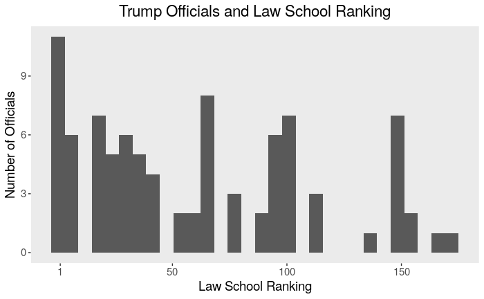